# Week 1: Data Import, Manipulation, and GitHub

# Objectives:

- Set up and configure GitHub for use within RStudio.
- Importing data in R (a quick overview).
- Data manipulation in R (a quick overview).

# Setup GitHub

Follow instructions on [Using Git with RStudio](https://jennybc.github.io/2014-05-12-ubc/ubc-r/session03_git.html).

For a Windows machine, generally, it is:

- Download and install [Git](https://git-scm.com/download/win).
- In RStudio, create an SSH key pair (follow instructions [here](https://happygitwithr.com/ssh-keys.html#create-an-ssh-key-pair)):
  - Go to Tools > Global Options… > Git/SVN.
  - Point to the executable “git.exe” (/Program Files/Git/)
  - Create RSA key in RStudio.
  - Copy RSA key. Add the generated key by clicking “new SSH key” into GitHub under your profile’s settings > SSH and GPG keys, and pasting it.
- Open git bash executable, and change directory (`cd`) to the folder you want to save the repo in.
- Run the following:

```
git clone https://github.com/engineerchange/r-dsandml-exercises.git
```

- Open .Rproj file in RStudio.
- Then go to Tools > Project Options… > Git/Svn to configure.
- From there, you should see a “Git” tab in the Environment pane where you can Commit, Pull, and Push.

# Importing

Load in necessary libraries.

Data is sourced from Euro Spatial Diffusion Observatory (ESDO) in-person surveys between 2002 and 2011 in France. From [Mendeley](https://data.mendeley.com/datasets/f257j67ym6/2).

```r
library(tidyverse)
library(gghighlight)
library(gt)
library(arrow)
library(microbenchmark) # to do simple benchmarking
dir = here::here()
df = read_csv2(paste0(dir,"/lessons/data/DB_ESDO_FRANCE_2002-2011.csv")) # initial un-cached dataset
```

Compare both:

```r
# note we use read.csv2 and read_csv2 because these files are delineated with semi-colons.

func1 <- function(){read.csv2(paste0(dir,"/lessons/data/DB_ESDO_FRANCE_2002-2011.csv"))}
func2 <- function(){read_csv2(paste0(dir,"/lessons/data/DB_ESDO_FRANCE_2002-2011.csv"))}

out = microbenchmark(times=20, unit="ms", func1(), func2())
print(out)
```

```
## Unit: milliseconds
##     expr       min        lq      mean    median       uq      max neval
##  func1()  879.6328  899.4481  958.2334  943.4141 1019.720 1052.004    20
##  func2() 7846.5290 7901.4857 7940.6658 7942.7827 7959.366 8057.777    20
```

Can potentially speed up operations after by saving as RDS or arrow’s parquet.

```r
df = read_csv2(paste0(dir,"/lessons/data/DB_ESDO_FRANCE_2002-2011.csv"))

func1 <- function(){write_rds(df,paste0(dir,"/lessons/data/out.RDS"))}
func2 <- function(){write_parquet(df,paste0(dir,"/lessons/data/out.parquet"))}

out = microbenchmark(times=20, unit="ms", func1(), func2())
print(out)
```

```
## Unit: milliseconds
##     expr      min       lq     mean   median       uq      max neval
##  func1() 120.4817 124.8675 147.7108 126.9510 134.5909 452.6272    20
##  func2() 157.6626 169.4073 187.4401 174.3022 184.2747 348.9838    20
```

Can potentially speed up read times with parquet over standard RDS.

```r
func1 <- function(){read_rds(paste0(dir,"/lessons/data/out.RDS"))}
func2 <- function(){read_parquet(paste0(dir,"/lessons/data/out.parquet"))}

out = microbenchmark(times=20, unit="ms", func1(), func2())
print(out)
```

```
## Unit: milliseconds
##     expr      min       lq      mean   median       uq       max neval
##  func1() 66.54348 76.17840 105.47231 80.79832 99.72046 224.40722    20
##  func2() 31.72690 37.55083  45.33556 44.11416 48.94922  78.18824    20
```

Try just reading in specific columns starting with QFRA.

```r
func1 <- function(){read_rds(paste0(dir,"/lessons/data/out.RDS")) %>% select(starts_with("QFRA"))}
func2 <- function(){read_parquet(paste0(dir,"/lessons/data/out.parquet"),col_select = starts_with("QFRA"))}

out = microbenchmark(times=20, unit="ms", func1(), func2())
print(out)
```

```
## Unit: milliseconds
##     expr       min        lq      mean   median       uq       max neval
##  func1() 65.241377 77.612012 102.49225 86.27695 95.64719 219.83685    20
##  func2()  8.723225  9.418664  11.77055 10.71331 12.07266  20.65433    20
```

# Data Manipulation

Get an idea of what data there is.

```r
head(df,5)
```

| SURVEY | SEX | AGE | AGGL_FR_5 | NUTS3 | NPF5 | E15 | PRO6_FR | PRO6_FR_CF | SIT_SAL | SAL | TPS_FR | SIT_CF | SAL_CF | TPS_FR_CF | COUPLE | STM | DIPLIN_FR | HAB_TYP | HAB_STAT | REVR_FR | Weight | QFRA_1c | QFRA_2c | QFRA_5c | QFRA_10c | QFRA_20c | QFRA_50c | QFRA_1e | QFRA_2e | … |
| --- | --- | --- | --- | --- | --- | --- | --- | --- | --- | --- | --- | --- | --- | --- | --- | --- | --- | --- | --- | --- | --- | --- | --- | --- | --- | --- | --- | --- | --- | --- |
| 01/03/2002 | 2 | 47 | 1 | FR711 | 4 | 0 | 6 | 5 | 0 | 0 | 0 | 2 | 3 | 1 | 1 | 1 | 1 | 3 | 1 | 9 | 0.898741 | 0 | 0 | 0 | 0 | 0 | 0 | 0 | 0 | … |
| 01/03/2002 | 2 | 34 | 1 | FR711 | 3 | 1 | 4 | 3 | 2 | 3 | 1 | 2 | 3 | 1 | 1 | 1 | 4 | 3 | 1 | 5 | 0.853786 | 1 | 2 | 0 | 0 | 2 | 0 | 1 | 1 | … |
| 01/03/2002 | 1 | 25 | 3 | FR711 | 3 | 1 | 5 | 5 | 2 | 3 | 1 | 0 | 0 | 0 | 1 | 1 | 3 | 3 | 2 | 4 | 0.792366 | 2 | 1 | 2 | 0 | 0 | 0 | 0 | 0 | … |
| 01/03/2002 | 1 | 55 | 3 | FR711 | 2 | 0 | 6 | 6 | 2 | 1 | 1 | 0 | 0 | 0 | 1 | 1 | 2 | 3 | 1 | 6 | 1.074985 | 1 | 1 | 1 | 5 | 1 | 0 | 4 | 0 | … |
| 01/03/2002 | 1 | 61 | 3 | FR711 | 2 | 0 | 6 | 6 | 2 | 3 | 1 | 0 | 0 | 0 | 1 | 1 | 3 | 3 | 1 | 3 | 1.074985 | 3 | 0 | 0 | 0 | 3 | 0 | 0 | 1 | … |

```r
# read metadata

df2 = read_csv2(paste0(dir,"/lessons/data/metadataDB_ESDO_FRANCE_2002-2011.csv"))
head(df2,20)
```

| SURVEY | Month and year of the survey |
| --- | --- |
| SEX | 1) Man 2) Woman |
| AGE | Age in years |
| AGGL_FR_5 | Place of residence type of agglomeration in 5 categories: 1) Rural 2) from 2,000 to 20,000 inhabitants 3) from 20,000 to 100,000 inhabitants 4) >100,000 inhabitants 5) Paris agglomeration |
| NUTS3 | Place of residence location according to the European Nomenclature of Territorial Units for Statistics at level 3 |
| NPF5 | Size of the household in 5 categories : 1) 1 person 2) 2 persons 3) 3 persons 4) 4 persons 5) 5 persons and more |
| E15 | Number of children under age 15 in 6 categories: 0) none 1) 1 child 2) 2 children 3) 3 children 4) 4 children 5) 5 children and more |
| PRO6_FR | Profession in 6 categories: 1) Farmer 2) Craftsman - seller 3) Manager 4) Intermediate profession, employee 5) Worker 6) Inactive |
| PRO6_FR_CF | Profession of the head of the family, if the head of household in not the respondent, in 6 categories: 1) Farmer 2) Craftsman - seller 3) Manager 4) Intermediate profession, employee 5) Worker 6) Inac… |
| SIT_SAL | Current or past salary situation in 2 categories: 1) On your account 2) Employment |
| SAL | Employer type in 3 categories: 1) state or local community 2) public company 3) private company |

[output cut: 10 more lines]

```r
head(df2 %>% slice(20:nrow(df2)),20)
```

| SURVEY | Month and year of the survey |
| --- | --- |
| REVR_FR | In the first 15 surveys (March 2002 to October 2008), the respondent's average gross income is categorized according to the following thresholds: 1) 6099 EUROS 11) Refuse to answer the question 12) NA… |
| Weight | Weighting variables constructed by ISL |
| QFRA_1c | Number of 01 cent coins minted in France contained in the wallet |
| QFRA_2c | Number of 02 cents coins minted in France contained in the wallet |
| QFRA_5c | Number of 05 cents coins minted in France contained in the wallet |
| QFRA_10c | Number of 10 cents coins minted in France contained in the wallet |
| QFRA_20c | Number of 20 cents coins minted in France contained in the wallet |
| QFRA_50c | Number of 50 cents coins minted in France contained in the wallet |
| QFRA_1e | Number of 1 euro coins minted in France contained in the wallet |
| QFRA_2e | Number of 2 euros coins minted in France contained in the wallet |

[output cut: 10 more lines]

Apparently, there are a lot of columns of extra data, so we exclude to just the France coin related columns and demographics we want.

```r
df = df %>% select(SURVEY:AGE,starts_with("QFRA"))
head(df)
```

| SURVEY | SEX | AGE | QFRA_1c | QFRA_2c | QFRA_5c | QFRA_10c | QFRA_20c | QFRA_50c | QFRA_1e | QFRA_2e |
| --- | --- | --- | --- | --- | --- | --- | --- | --- | --- | --- |
| 01/03/2002 | 2 | 47 | 0 | 0 | 0 | 0 | 0 | 0 | 0 | 0 |
| 01/03/2002 | 2 | 34 | 1 | 2 | 0 | 0 | 2 | 0 | 1 | 1 |
| 01/03/2002 | 1 | 25 | 2 | 1 | 2 | 0 | 0 | 0 | 0 | 0 |
| 01/03/2002 | 1 | 55 | 1 | 1 | 1 | 5 | 1 | 0 | 4 | 0 |
| 01/03/2002 | 1 | 61 | 3 | 0 | 0 | 0 | 3 | 0 | 0 | 1 |
| 01/03/2002 | 1 | 37 | 4 | 0 | 2 | 0 | 3 | 0 | 0 | 0 |

We may want to get an idea of the average proportion of different coin types by individual. So we can graph that.

```r
# Make data in long form

df_long = df %>%
  mutate(Person=row_number()) %>%
  pivot_longer(cols=starts_with("QFRA"),names_to = "Coin", values_to = "Count")
head(df_long,5)
```

| SURVEY | SEX | AGE | Person | Coin | Count |
| --- | --- | --- | --- | --- | --- |
| 01/03/2002 | 2 | 47 | 1 | QFRA_1c | 0 |
| 01/03/2002 | 2 | 47 | 1 | QFRA_2c | 0 |
| 01/03/2002 | 2 | 47 | 1 | QFRA_5c | 0 |
| 01/03/2002 | 2 | 47 | 1 | QFRA_10c | 0 |
| 01/03/2002 | 2 | 47 | 1 | QFRA_20c | 0 |

```r
# Separate out column Coin

df_long = df_long %>%
  separate(Coin,sep="_",into = c("Lbl","Coin"))
head(df_long,5)
```

| SURVEY | SEX | AGE | Person | Lbl | Coin | Count |
| --- | --- | --- | --- | --- | --- | --- |
| 01/03/2002 | 2 | 47 | 1 | QFRA | 1c | 0 |
| 01/03/2002 | 2 | 47 | 1 | QFRA | 2c | 0 |
| 01/03/2002 | 2 | 47 | 1 | QFRA | 5c | 0 |
| 01/03/2002 | 2 | 47 | 1 | QFRA | 10c | 0 |
| 01/03/2002 | 2 | 47 | 1 | QFRA | 20c | 0 |

```r
# remove column Lbl

df_long = df_long %>% select(-Lbl)
head(df_long,5)
```

| SURVEY | SEX | AGE | Person | Coin | Count |
| --- | --- | --- | --- | --- | --- |
| 01/03/2002 | 2 | 47 | 1 | 1c | 0 |
| 01/03/2002 | 2 | 47 | 1 | 2c | 0 |
| 01/03/2002 | 2 | 47 | 1 | 5c | 0 |
| 01/03/2002 | 2 | 47 | 1 | 10c | 0 |
| 01/03/2002 | 2 | 47 | 1 | 20c | 0 |

```r
# rearrange columns

df_long = df_long %>% select(Person,SURVEY,SEX,AGE,everything())
head(df_long,5)
```

| Person | SURVEY | SEX | AGE | Coin | Count |
| --- | --- | --- | --- | --- | --- |
| 1 | 01/03/2002 | 2 | 47 | 1c | 0 |
| 1 | 01/03/2002 | 2 | 47 | 2c | 0 |
| 1 | 01/03/2002 | 2 | 47 | 5c | 0 |
| 1 | 01/03/2002 | 2 | 47 | 10c | 0 |
| 1 | 01/03/2002 | 2 | 47 | 20c | 0 |

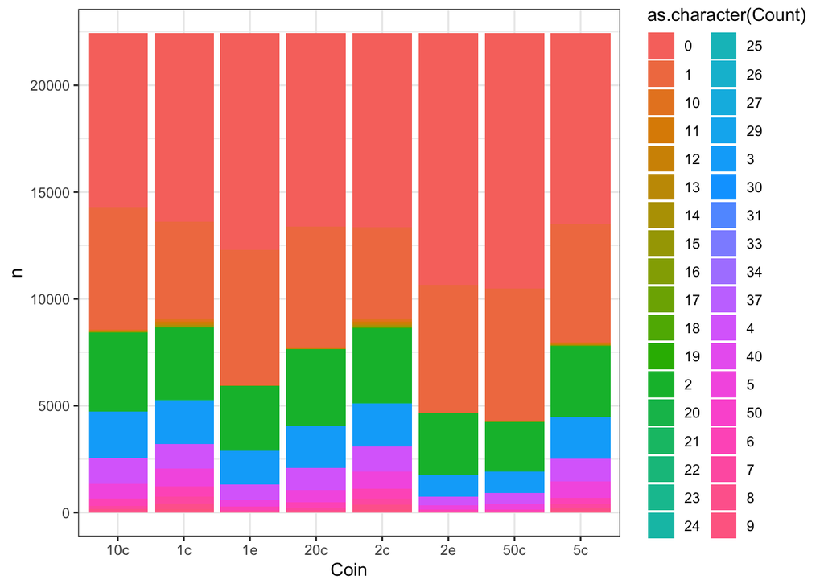

```r
# make initial bar chart

df_long %>% group_by(Coin,Count) %>% count() %>% ungroup() %>%
  ggplot() + theme_bw() +
  geom_bar(aes(x=Coin,y=n,fill=as.character(Count)),stat='identity',position='stack')
```

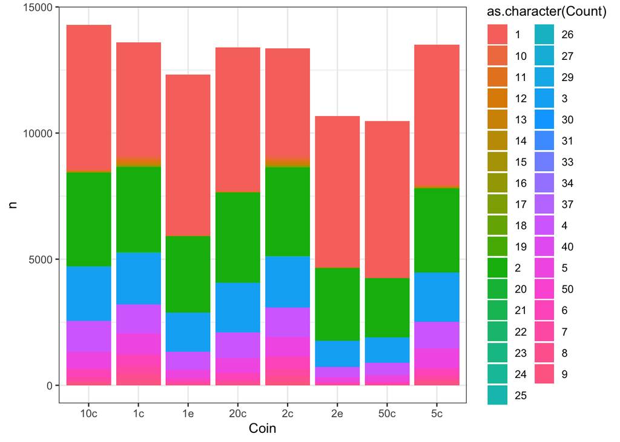

```r
# make bar chart ignoring 0 counts

df_long %>% dplyr::filter(Count!="0") %>%
  group_by(Coin,Count) %>% count() %>% ungroup() %>%
  ggplot() + theme_bw() +
  geom_bar(aes(x=Coin,y=n,fill=as.character(Count)),stat='identity',position='stack')
```

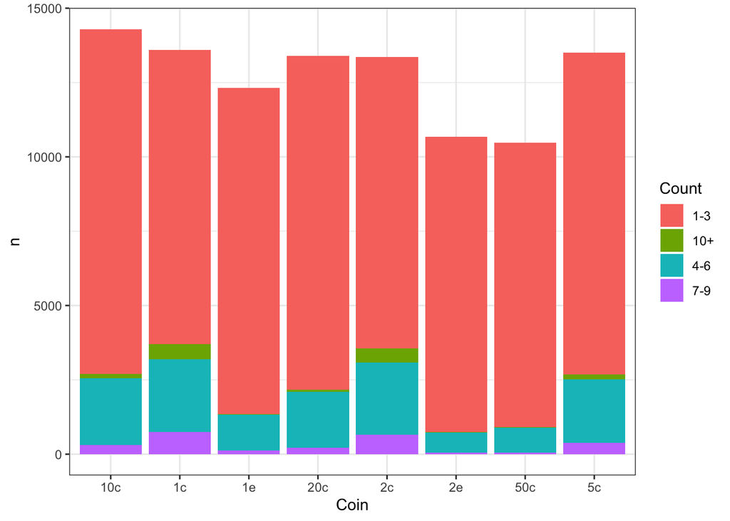

```r
# group coins into buckets

df_long %>% dplyr::filter(Count!="0") %>%
  mutate(Count=case_when(
    Count %in% c(1,2,3) ~ "1-3",
    Count %in% c(4,5,6) ~ "4-6",
    Count %in% c(7,8,9) ~ "7-9",
    TRUE ~ "10+"
  )) %>%
  group_by(Coin,Count) %>% count() %>% ungroup() %>%
  ggplot() + theme_bw() +
  geom_bar(aes(x=Coin,y=n,fill=Count),stat='identity',position='stack')
```

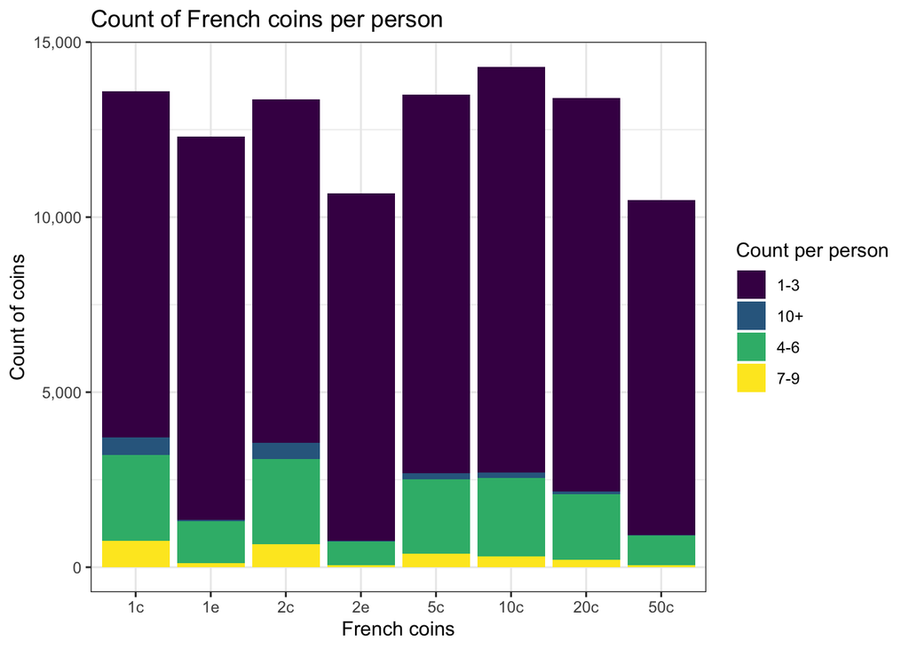

```r
# clean up: add axis labels, title, scale axis, viridis discrete scale

df_long %>% dplyr::filter(Count!="0") %>%
  mutate(Count=case_when(
    Count %in% c(1,2,3) ~ "1-3",
    Count %in% c(4,5,6) ~ "4-6",
    Count %in% c(7,8,9) ~ "7-9",
    TRUE ~ "10+"
  )) %>%
  group_by(Coin,Count) %>% count() %>% ungroup() %>%
  ggplot() + theme_bw() +
  geom_bar(aes(x=factor(Coin, level = c("1c","1e","2c","2e","5c","10c","20c","50c")),y=n,fill=Count),
           stat='identity',position='stack') +
  scale_x_discrete(name="French coins") +
  scale_y_continuous(name="Count of coins",labels = scales::comma) +
  ggtitle("Count of French coins per person") +
  scale_fill_viridis_d(name="Count per person")
```

# Exploratory Data Analysis (EDA)

Exploratory Data Analysis is a fancy way of saying explore the data.

Why?  
- Understand what data there is (features, records, relationships, etc.)  
- Under what data there isn’t (features missing, data missing)  
- Data problems (misspellings, variable usage / data collection over time, missing data)  
- Distribution of data (is it normally distributed? is it a sample?)

TL;DR - we ask questions of the data before doing any modelling.

Let’s look at dates of these surveys.

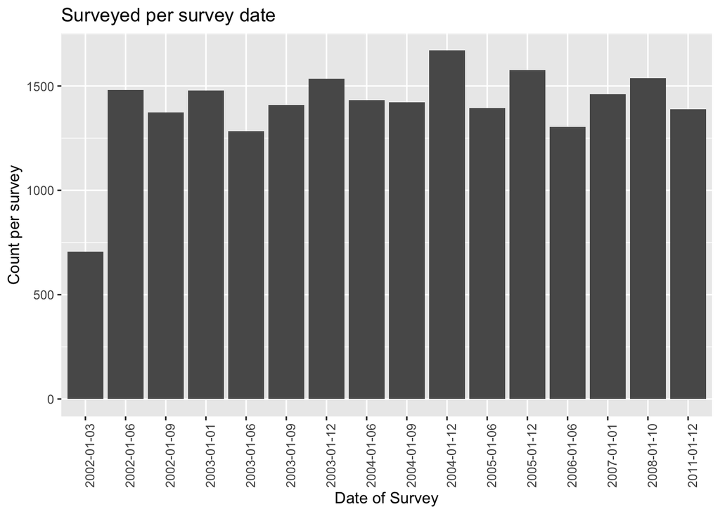

```r
df %>% mutate(SURVEY=as.Date(SURVEY,"%m/%d/%Y") %>% as.character()) %>%
  group_by(SURVEY) %>% count() %>% ungroup() %>%
  ggplot() +
  geom_bar(aes(x=SURVEY,y=n),stat='identity') +
  theme(axis.text.x = element_text(angle=90, hjust=1)) +
  scale_x_discrete(name="Date of Survey") + scale_y_continuous(name="Count per survey") +
  ggtitle("Surveyed per survey date")
```

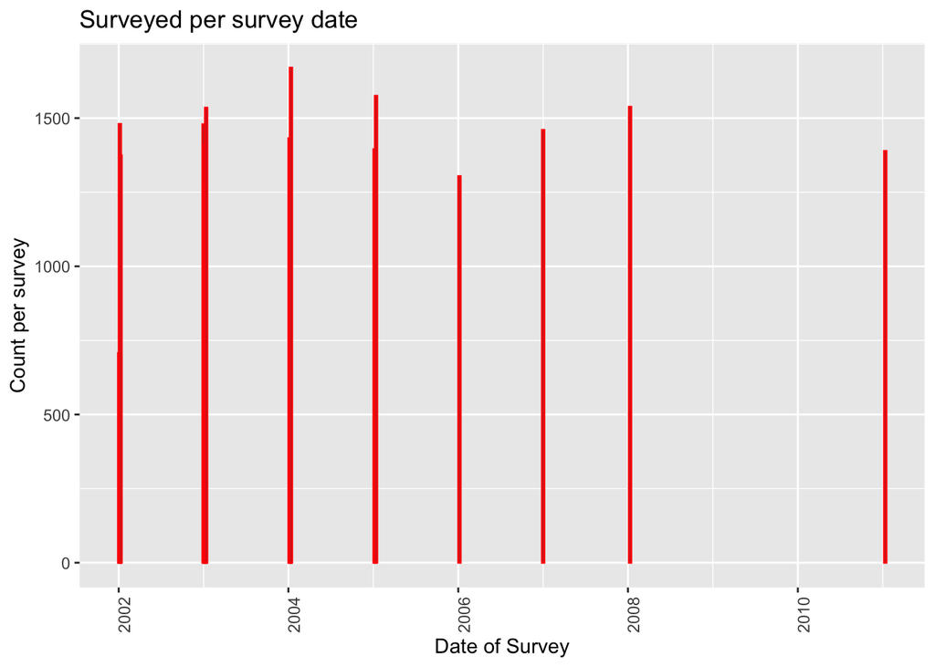

```r
# do with date
df %>% mutate(SURVEY=as.Date(SURVEY,"%m/%d/%Y")) %>%
  group_by(SURVEY) %>% count() %>% ungroup() %>%
  ggplot() +
  geom_bar(aes(x=SURVEY,y=n,group=SURVEY),stat='identity',width = 10,colour="red") +
  theme(axis.text.x = element_text(angle=90, hjust=1)) +
  scale_x_date(name="Date of Survey") + scale_y_continuous(name="Count per survey") +
  ggtitle("Surveyed per survey date")
```

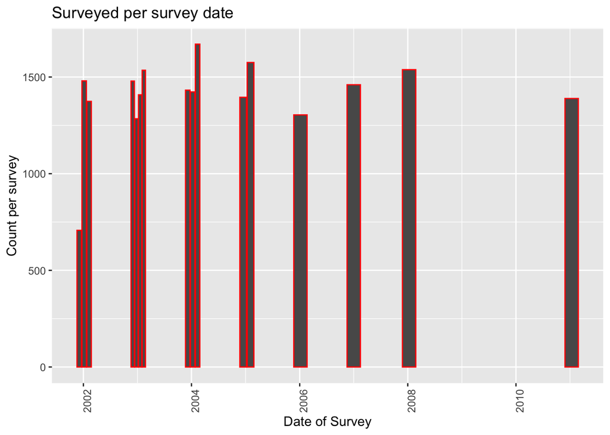

```r
# do our best to dodge the bars
df %>% mutate(SURVEY=as.Date(SURVEY,"%m/%d/%Y")) %>%
  group_by(SURVEY) %>% count() %>% ungroup() %>%
  ggplot() +
  geom_bar(aes(x=SURVEY,y=n,group=SURVEY),stat='identity',width = 100,colour="red",position="dodge2") +
  theme(axis.text.x = element_text(angle=90, hjust=1)) +
  scale_x_date(name="Date of Survey") + scale_y_continuous(name="Count per survey") +
  ggtitle("Surveyed per survey date")
```

Let’s look at age.

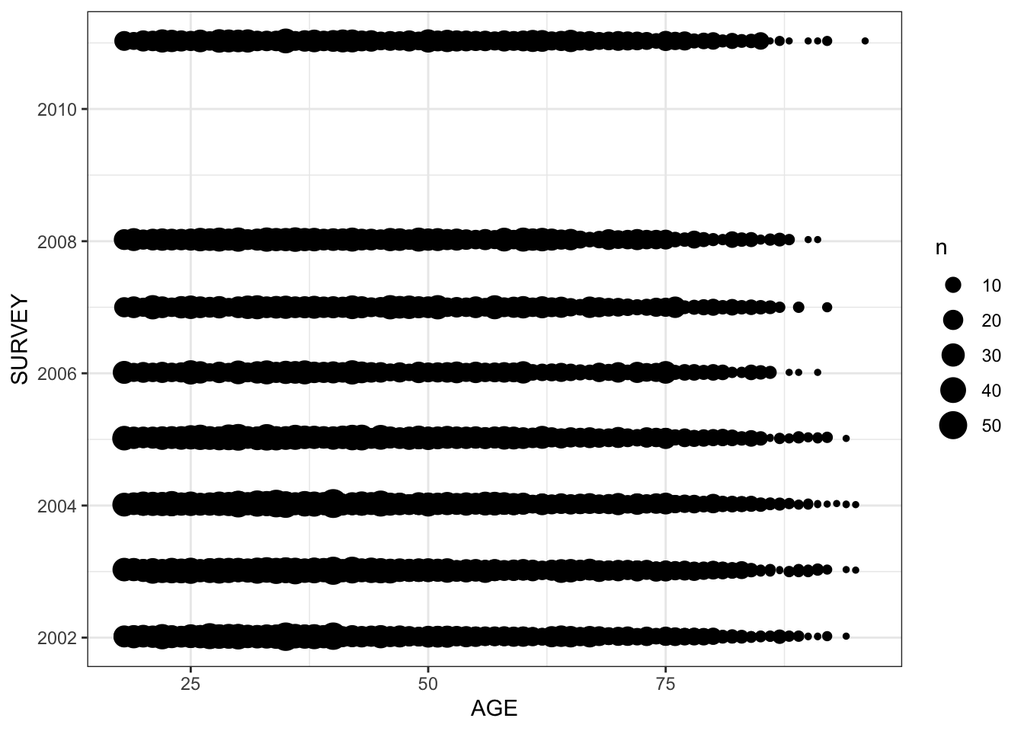

```r
# try to graph age by survey
df %>% mutate(SURVEY=as.Date(SURVEY,"%m/%d/%Y")) %>%
    group_by(SURVEY,AGE) %>% count() %>% ungroup() %>%
  ggplot() + geom_point(aes(x=AGE,y=SURVEY,size=n)) +
  theme_bw()
```

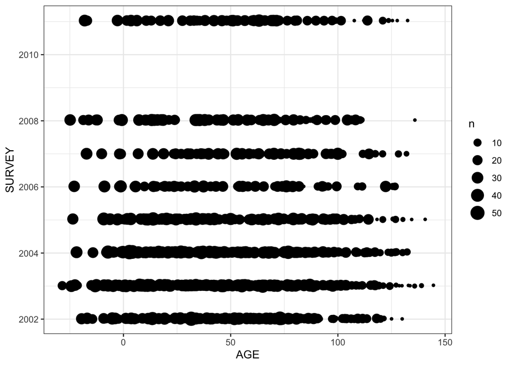

```r
# let's jitter the points
df %>% mutate(SURVEY=as.Date(SURVEY,"%m/%d/%Y")) %>%
    group_by(SURVEY,AGE) %>% count() %>% ungroup() %>%
  ggplot() + geom_jitter(aes(x=AGE,y=SURVEY,size=n),width=50) +
  theme_bw()
```

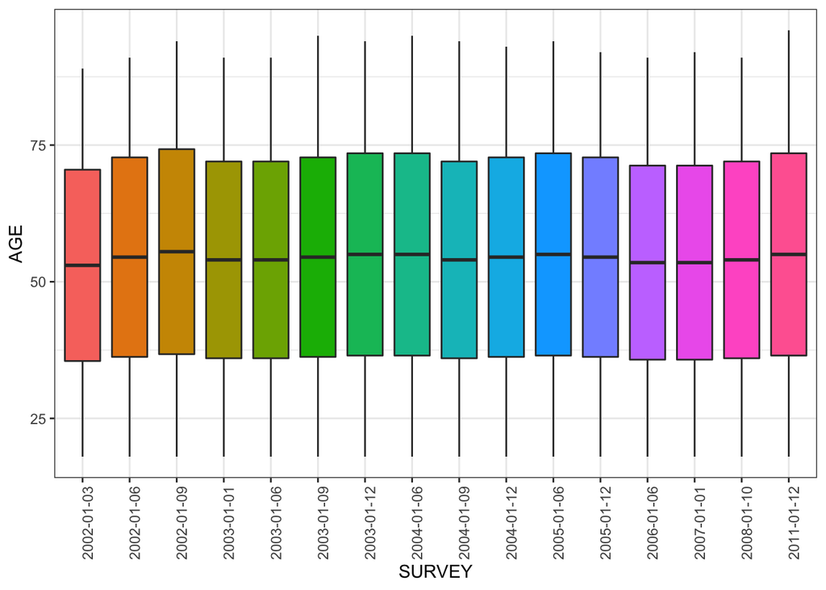

```r
# boxplot
df %>% mutate(SURVEY=as.Date(SURVEY,"%m/%d/%Y") %>% as.character()) %>%
    group_by(SURVEY,AGE) %>% count() %>% ungroup() %>%
  ggplot() + geom_boxplot(aes(x=SURVEY,y=AGE,fill=SURVEY)) +
  scale_fill_discrete(guide="none") +
  theme_bw() +
  theme(axis.text.x = element_text(angle=90, hjust=1))
```

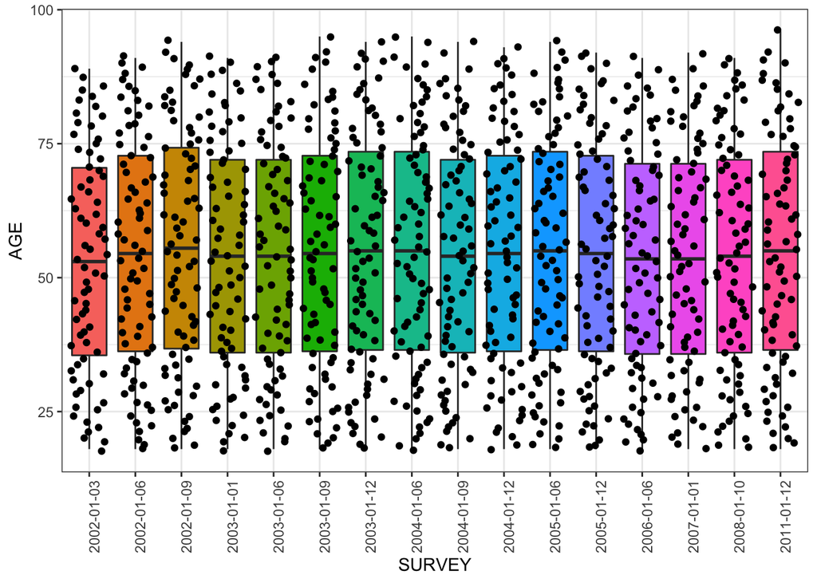

```r
# boxplot + points
df %>% mutate(SURVEY=as.Date(SURVEY,"%m/%d/%Y") %>% as.character()) %>%
    group_by(SURVEY,AGE) %>% count() %>% ungroup() %>%
  ggplot(aes(x=SURVEY,y=AGE,fill=SURVEY)) +
  geom_boxplot() +
  geom_jitter() +
  scale_fill_discrete(guide="none") +
  theme_bw() +
  theme(axis.text.x = element_text(angle=90, hjust=1))
```

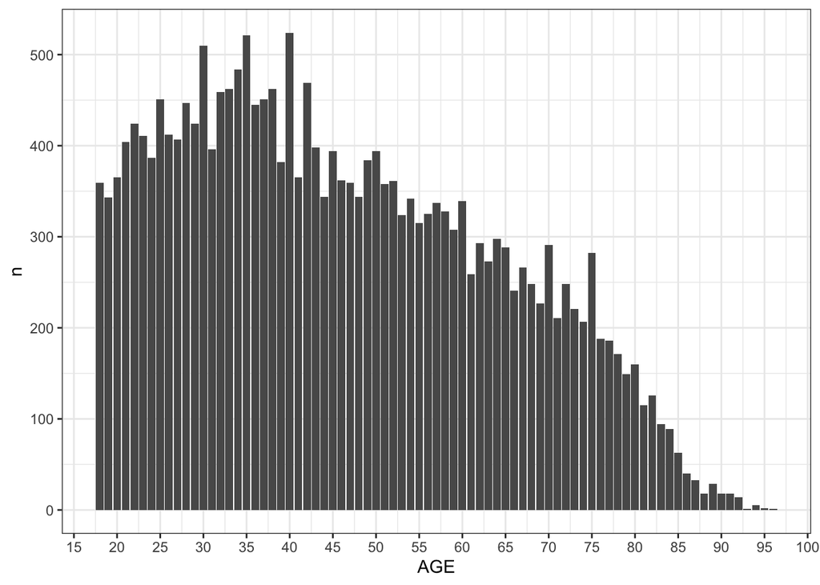

```r
# distribution of age
df %>% group_by(AGE) %>% count() %>% ungroup() %>%
  ggplot() +
  geom_bar(aes(x=AGE,y=n),stat='identity') +
  scale_x_continuous(breaks=c(seq(0,100,5))) +
  theme_bw()
```

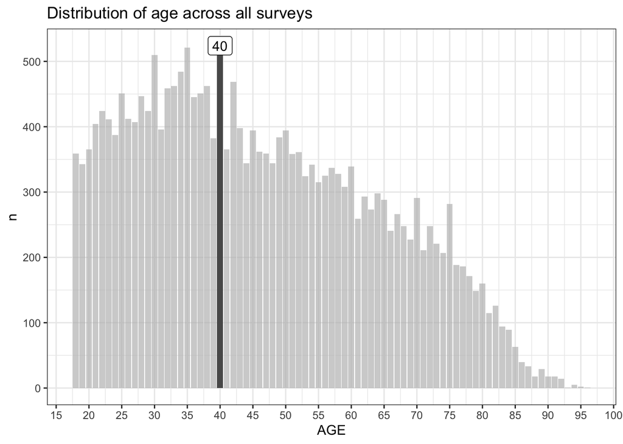

```r
# gghighlight
df %>% group_by(AGE) %>% count() %>% ungroup() %>%
  ggplot() +
  geom_bar(aes(x=AGE,y=n),stat='identity') +
  scale_x_continuous(breaks=c(seq(0,100,5))) +
  gghighlight(AGE==40) +
  geom_label(aes(x=AGE,y=n,label=AGE)) +
  theme_bw() +
  ggtitle("Distribution of age across all surveys")
```

```r
df %>%
  mutate(AGE_GROUP = case_when(
    AGE < 20 ~ "<20",
    AGE >= 20 & AGE <30 ~ "20s",
    AGE >= 30 & AGE <40 ~ "30s",
    AGE >= 40 & AGE <50 ~ "40s",
    AGE >= 50 & AGE <60 ~ "50s",
    AGE >= 60 & AGE <70 ~ "60s",
    AGE >= 70 & AGE <80 ~ "70s",
    AGE >= 80 & AGE <90 ~ "80s",
    AGE >= 90 & AGE <100 ~ "90s",
    AGE >= 100 ~ "100+",
    TRUE ~ "ELSE"
  )) %>%
  group_by(AGE_GROUP) %>% count() %>% ungroup() %>%
  gt()
```

| AGE_GROUP | n |
| --- | --- |
| <20 | 702 |
| 20s | 4132 |
| 30s | 4572 |
| 40s | 3943 |
| 50s | 3392 |
| 60s | 2732 |
| 70s | 2154 |
| 80s | 767 |
| 90s | 59 |

# Resources

## GitHub

- [Using Git with RStudio](https://jennybc.github.io/2014-05-12-ubc/ubc-r/session03_git.html), Jenny Bryan
- [Happy Git with R](https://happygitwithr.com/), Jenny Bryan

## Importing

- [R for Data Science - Data Import](https://r4ds.had.co.nz/data-import.html)
- [Efficient input/output](https://csgillespie.github.io/efficientR/input-output.html)
- [Apache Arrow](https://arrow.apache.org/docs/r/reference/index.html)